# Example: Continuous data imputation through GLM

### Data from an antidepressant clinical trial

The example data can be found in [DIA Missing Data](https://www.lshtm.ac.uk/research/centres-projects-groups/missing-data#dia-missing-data) webpage. Original data was from an antidepressant clinical trial with four treatments; two doses of an experimental medication, a positive control, and placebo. Hamilton 17-item rating scale for depression (HAMD17) was observed at baseline and its change scores at weeks 1, 2, 4, 6, and 8 ( [Goldstein et al. 2004](https://doi.org/10.1097/01.jcp.0000132448.65972.d9)). To mask the real data Week-8 observations were removed. The example data is a sub-sample of the original data: two arms were created; the original placebo arm and a “drug arm” created by randomly selecting patients from the three non-placebo arms.

```r
data(antidep)
head(antidep) %>% kbl(align = "c") %>%
  kable_classic(full_width = F, html_font = "Cambria") %>%
  column_spec(1:2, width = "2cm") %>%
  add_header_above(c(" " = 1, " "=1, "Responses at the baseline, week 1, 2, 4, and 6" = 5))
```

| PID | tx | Responses at the baseline, week 1, 2, 4, and 6 y0 | Responses at the baseline, week 1, 2, 4, and 6 y1 | Responses at the baseline, week 1, 2, 4, and 6 y2 | Responses at the baseline, week 1, 2, 4, and 6 y4 | Responses at the baseline, week 1, 2, 4, and 6 y6 |
| --- | --- | --- | --- | --- | --- | --- |
| 1503 | 1 | 32 | -11 | -12 | -13 | -15 |
| 1507 | 0 | 14 | -3 | 0 | -5 | -9 |
| 1509 | 1 | 21 | -1 | -3 | -5 | -8 |
| 1511 | 0 | 21 | -5 | -3 | -3 | -9 |
| 1513 | 1 | 19 | 5 | NA | NA | NA |
| 1514 | 0 | 21 | 2 | NA | NA | NA |

Missing pattern is displayed in the following plot:

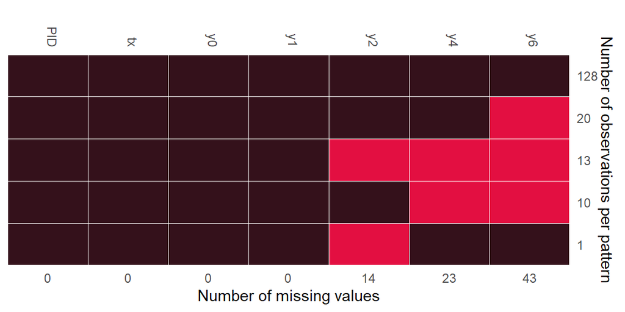

Missing pattern of antidepressant data

```r
registerDoFuture()
plan(multisession(workers = 4))

an.test = remiod(formula=y6 ~ tx + y0 + y1 + y2 + y4, data=antidep, family = gaussian(),
                 models = c(y2="glm_gaussian_identity",y4="glm_gaussian_identity"),
                 n.iter = 100000,  n.chains = 4, n.adapt = 10000, thin=100,
                 algorithm = "jags", trtvar = 'tx', method="MAR", mess=TRUE, warn=FALSE)

plan(sequential)
```

The following plots show trace plots and the estimated intervals as shaded areas under the posterior density curves for the parameters of treatment variable `tx` in imputation models:

- `beta[2]` is the coefficient of `tx` in imputation model `y6 ~ tx + y0 + y1 + y2 + y4`;
- `alpha[2]` is the coefficient of `tx` in imputation model `y4 ~ tx + y0 + y1 + y2`;
- `alpha[7]` is the coefficient of `tx` in imputation model `y2 ~ tx + y0 + y1`;

The specified set of parameters can be submitted through argument `subset` with keyword `selected_vars` (alternatively, keyword `selected_parms` can be used):

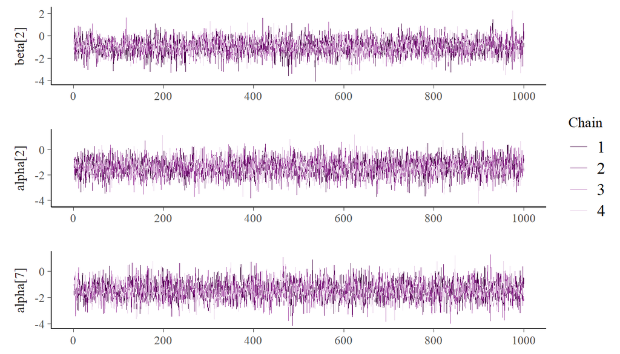

Traceplot for coefficients of `tx` in imputation models

```r
mcsub = get_subset(object = an.test$mc.mar, subset=c(selected_vars = list("tx")))

color_scheme_set("purple")
mcmc_trace(mcsub, facet_args = list(ncol = 1, strip.position = "left"))
```

```r
mcmc_areas(
  mcsub,
  prob = 0.95, # 95% intervals
  prob_outer = 0.99,
  point_est = "mean"
)
```

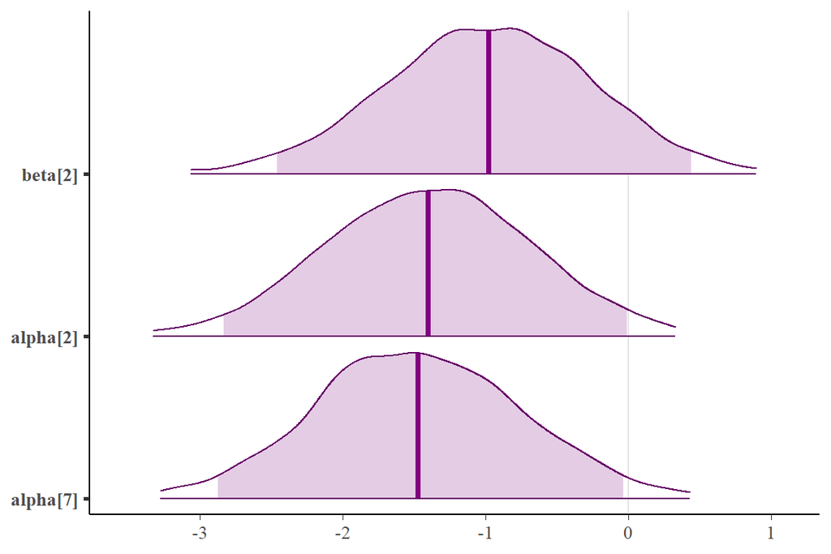

Intervals under the estimated posterior density curves for coefficients of `tx` in imputation models

To obtain jump-to-reference analysis, we extract MI data with `method="J2R"`, and pool analysis results with `miAnalyze`:

```r
j2r = extract_MIdata(object=an.test, method="J2R", M=1000, minspace=4)
res.j2r = miAnalyze(formula = y6 ~ y0 + tx, data = j2r, family = gaussian())

data.frame(res.j2r$Est.pool) %>% select(-6) %>%
  mutate_if(is.numeric, format, digits=4,nsmall = 0) %>%
  kbl(align = "c") %>%
  kable_classic(full_width = F, html_font = "Cambria")
```

|  | Estimate | SE | CI.low | CI.up | t |
| --- | --- | --- | --- | --- | --- |
| (Intercept) | 1.0433 | 1.82704 | -2.5376 | 4.6243 | 0.5711 |
| y0 | -0.3292 | 0.09697 | -0.5192 | -0.1391 | -3.3945 |
| tx | -2.3558 | 1.04973 | -4.4133 | -0.2984 | -2.2442 |

#### Reference

Wang, T. and Liu, Y. 2022. “Remiod: Reference-Based Controlled Multiple Imputation of Longitudinal Binary and Ordinal Outcomes with Non-Ignorable Missingness.” [arxiv 2203.02771](https://arxiv.org/pdf/2203.02771).

Goldstein, David J. MD, PhD; Lu, Yili; Detke, Michael J.; Wiltse, Curtis; Mallinckrodt, Craig; Demitrack, Mark A. Duloxetine in the Treatment of Depression Journal of Clinical Psychopharmacology: 2004, 24(4) p 389-399 [doi: 10.1097/01.jcp.0000132448.65972.d9](https://journals.lww.com/psychopharmacology/Abstract/2004/08000/Duloxetine_in_the_Treatment_of_Depression__A.6.aspx)

## Vignettes

- Introduction to remiod
- Theoretical Background
- Example: Binary Data Imputation
- Example: Continuous Data Imputation Through GLM